# Introduction to ggplot()

Cheng Peng

West Chester University

# 1 Introduction

Data visualization becomes more effective when the colors are chosen carefully. It is convenient to have convenient color schemes ready for different type of data that are

- distinct for all people, including color-blind readers;
- distinct from black and white;
- distinct on screen and paper;
- matching well together.

This note discusses briefly such color schemes. A color scheme should reflect each of the three types of data:

**Qualitative data** - nominal or categorical data, where magnitude differences are not relevant. This includes lines in plots and text in presentations.

**Diverging data** - data ordered between two extremes where the midpoint is important, e.g. positive and negative deviations from zero or a mean.

**Sequential data** - data ordered from low to high.

# 2 Qualitative Color Schemes

There are several color blind safe color schemes for qualitative data. The following are short list of these suggested default schemes for further modifications. Qualitative color schemes are probably most important and used in data visualization.

- **Bright Scheme**

Bright qualitative color scheme that is color-blind safe. The main scheme for lines and their labels.

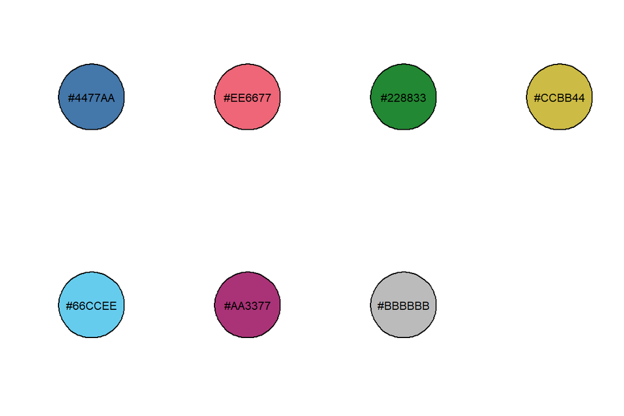

```r
par(mfrow=c(2,4))
plot(1:5,type="n", axes = FALSE, xlab = "", ylab = "")
draw.circle(3,3,2,col="#4477AA")
text(3,3, "#4477AA")
plot(1:5,type="n", axes = FALSE, xlab = "", ylab = "")
draw.circle(3,3,2,col="#EE6677")
text(3,3, "#EE6677")
plot(1:5,type="n", axes = FALSE, xlab = "", ylab = "")
draw.circle(3,3,2,col="#228833")
text(3,3, "#228833")
plot(1:5,type="n",axes = FALSE, xlab = "", ylab = "")
draw.circle(3,3,2,col="#CCBB44")
text(3,3, "#CCBB44")
plot(1:5,type="n", axes = FALSE, xlab = "", ylab = "")
draw.circle(3,3,2,col="#66CCEE")
text(3,3, "#66CCEE")
plot(1:5,type="n", axes = FALSE, xlab = "", ylab = "")
draw.circle(3,3,2,col="#AA3377")
text(3,3, "#AA3377")
plot(1:5,type="n", axes = FALSE, xlab = "", ylab = "")
draw.circle(3,3,2,col="#BBBBBB")
text(3,3, "#BBBBBB")
```

- **High-contrast Scheme**

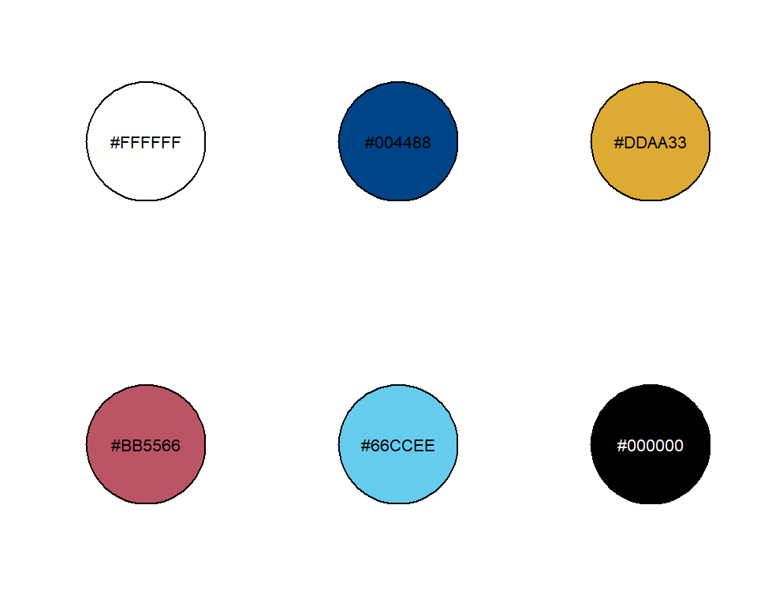

```r
par(mfrow=c(2,3))
plot(1:5,type="n", axes = FALSE, xlab = "", ylab = "", cex = 0.8)
draw.circle(3,3,2,col="#FFFFFF")
text(3,3, "#FFFFFF")
plot(1:5,type="n", axes = FALSE, xlab = "", ylab = "")
draw.circle(3,3,2,col="#004488")
text(3,3, "#004488")
plot(1:5,type="n", axes = FALSE, xlab = "", ylab = "")
draw.circle(3,3,2,col="#DDAA33")
text(3,3, "#DDAA33")
plot(1:5,type="n",axes = FALSE, xlab = "", ylab = "")
draw.circle(3,3,2,col="#BB5566")
text(3,3, "#BB5566")
plot(1:5,type="n", axes = FALSE, xlab = "", ylab = "")
draw.circle(3,3,2,col="#66CCEE")
text(3,3, "#66CCEE")
plot(1:5,type="n", axes = FALSE, xlab = "", ylab = "")
draw.circle(3,3,2,col="#000000")
text(3,3, "#000000", col = "#FFFFFF")
```

- **Vibrant Scheme**

Vibrant qualitative color scheme, an alternative to the bright scheme that is equally color-blind safe. It has been designed for data visualization framework.

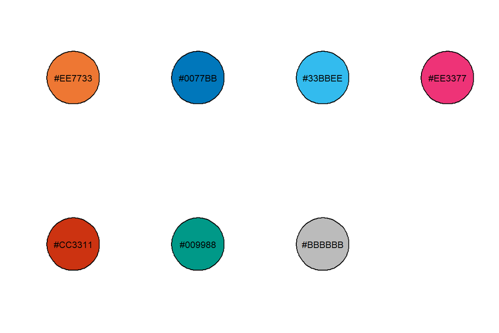

```r
par(mfrow=c(2,4))
plot(1:5,type="n", axes = FALSE, xlab = "", ylab = "")
draw.circle(3,3,2,col="#EE7733")
text(3,3, "#EE7733")
plot(1:5,type="n", axes = FALSE, xlab = "", ylab = "")
draw.circle(3,3,2,col="#0077BB")
text(3,3, "#0077BB")
plot(1:5,type="n", axes = FALSE, xlab = "", ylab = "")
draw.circle(3,3,2,col="#33BBEE")
text(3,3, "#33BBEE")
plot(1:5,type="n",axes = FALSE, xlab = "", ylab = "")
draw.circle(3,3,2,col="#EE3377")
text(3,3, "#EE3377")
plot(1:5,type="n", axes = FALSE, xlab = "", ylab = "")
draw.circle(3,3,2,col="#CC3311")
text(3,3, "#CC3311")
plot(1:5,type="n", axes = FALSE, xlab = "", ylab = "")
draw.circle(3,3,2,col="#009988")
text(3,3, "#009988")
plot(1:5,type="n", axes = FALSE, xlab = "", ylab = "")
draw.circle(3,3,2,col="#BBBBBB")
text(3,3, "#BBBBBB")
```

- **Muted Scheme**

Muted qualitative color scheme, an alternative to the bright scheme that is equally color-blind safe with more colours, but lacking a clear red or medium blue.

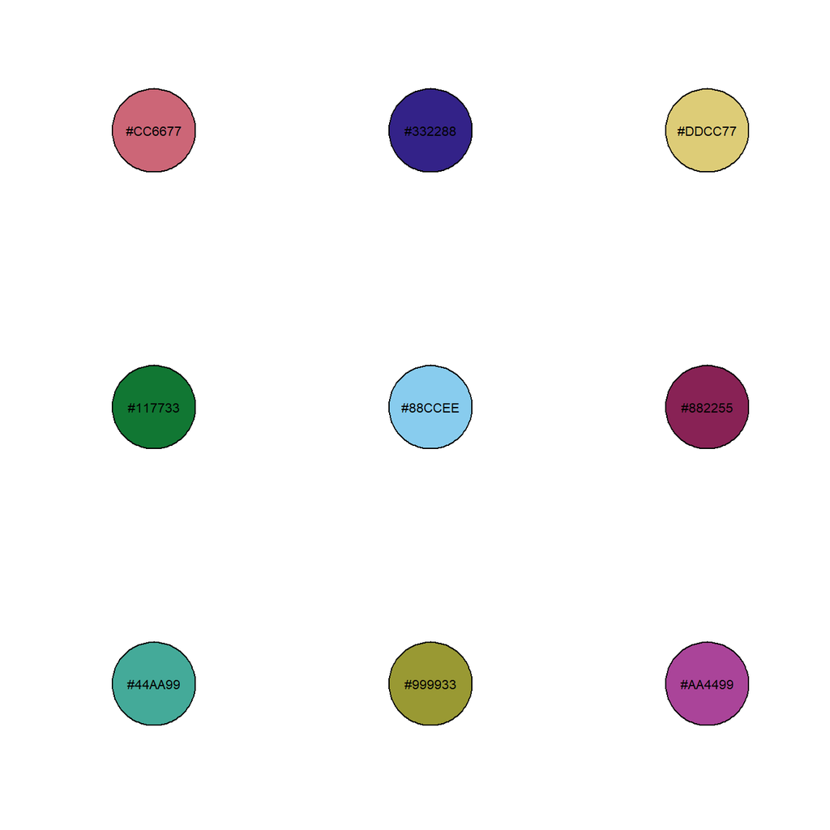

```r
par(mfrow=c(3,3))

plot(1:5,type="n", axes = FALSE, xlab = "", ylab = "")
draw.circle(3,3,1,col="#CC6677")
text(3,3, "#CC6677")
plot(1:5,type="n", axes = FALSE, xlab = "", ylab = "")
draw.circle(3,3,1,col="#332288")
text(3,3, "#332288")
plot(1:5,type="n", axes = FALSE, xlab = "", ylab = "")
draw.circle(3,3,1,col="#DDCC77")
text(3,3, "#DDCC77")
plot(1:5,type="n",axes = FALSE, xlab = "", ylab = "")
draw.circle(3,3,1,col="#117733")
text(3,3, "#117733")
plot(1:5,type="n", axes = FALSE, xlab = "", ylab = "")
draw.circle(3,3,1,col="#88CCEE")
text(3,3, "#88CCEE")
plot(1:5,type="n", axes = FALSE, xlab = "", ylab = "")
draw.circle(3,3,1,col="#882255")
text(3,3, "#882255")
plot(1:5,type="n",axes = FALSE, xlab = "", ylab = "")
draw.circle(3,3,1,col="#44AA99")
text(3,3, "#44AA99")
plot(1:5,type="n", axes = FALSE, xlab = "", ylab = "")
draw.circle(3,3,1,col="#999933")
text(3,3, "#999933")
plot(1:5,type="n", axes = FALSE, xlab = "", ylab = "")
draw.circle(3,3,1,col="#AA4499")
text(3,3, "#AA4499")
```

- **Medium-contrast Scheme**

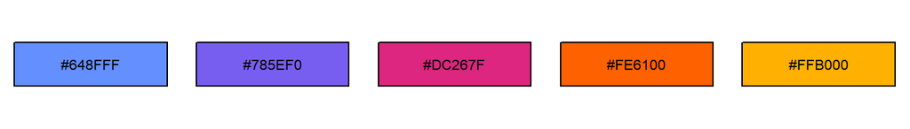

```r
par(mfrow=c(1,5), oma=c(0,0,0,0), mar = c(1,0.5,1,0.5))
plot(NULL, type="n", xlim=c(-1,1), ylim=c(-1,1), axes = FALSE, xlab = "", ylab = "")
rect(xleft = -1, ybottom = -0.5, xright =1, ytop = 0.5, lty = 1, col = "#648FFF")
text(0,0, "#648FFF")
plot(NULL, type="n", xlim=c(-1,1), ylim=c(-1,1), axes = FALSE, xlab = "", ylab = "")
rect(xleft = -1, ybottom = -0.5, xright =1, ytop = 0.5, lty = 1, col = "#785EF0")
text(0,0, "#785EF0")
plot(NULL, type="n", xlim=c(-1,1), ylim=c(-1,1), axes = FALSE, xlab = "", ylab = "")
rect(xleft = -1, ybottom = -0.5, xright =1, ytop = 0.5, lty = 1, col = "#DC267F")
text(0,0, "#DC267F")
plot(NULL, type="n", xlim=c(-1,1), ylim=c(-1,1), axes = FALSE, xlab = "", ylab = "")
rect(xleft = -1, ybottom = -0.5, xright =1, ytop = 0.5, lty = 1, col = "#FE6100")
text(0,0, "#FE6100")
plot(NULL, type="n", xlim=c(-1,1), ylim=c(-1,1), axes = FALSE, xlab = "", ylab = "")
rect(xleft = -1, ybottom = -0.5, xright =1, ytop = 0.5, lty = 1, col = "#FFB000")
text(0,0, "#FFB000")
```

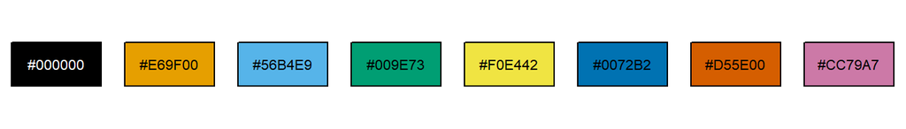

```r
par(mfrow=c(1,8), oma=c(0,0,0,0), mar = c(1,0.5,1,0.5))
plot(NULL, type="n", xlim=c(-1,1), ylim=c(-1,1), axes = FALSE, xlab = "", ylab = "")
rect(xleft = -1, ybottom = -0.5, xright =1, ytop = 0.5, lty = 1, col = "#000000")
text(0,0, "#000000", col = "white")
plot(NULL, type="n", xlim=c(-1,1), ylim=c(-1,1), axes = FALSE, xlab = "", ylab = "")
rect(xleft = -1, ybottom = -0.5, xright =1, ytop = 0.5, lty = 1, col = "#E69F00")
text(0,0, "#E69F00")
plot(NULL, type="n", xlim=c(-1,1), ylim=c(-1,1), axes = FALSE, xlab = "", ylab = "")
rect(xleft = -1, ybottom = -0.5, xright =1, ytop = 0.5, lty = 1, col = "#56B4E9")
text(0,0, "#56B4E9")
plot(NULL, type="n", xlim=c(-1,1), ylim=c(-1,1), axes = FALSE, xlab = "", ylab = "")
rect(xleft = -1, ybottom = -0.5, xright =1, ytop = 0.5, lty = 1, col = "#009E73")
text(0,0, "#009E73")
plot(NULL, type="n", xlim=c(-1,1), ylim=c(-1,1), axes = FALSE, xlab = "", ylab = "")
rect(xleft = -1, ybottom = -0.5, xright =1, ytop = 0.5, lty = 1, col = "#F0E442")
text(0,0, "#F0E442")
plot(NULL, type="n", xlim=c(-1,1), ylim=c(-1,1), axes = FALSE, xlab = "", ylab = "")
rect(xleft = -1, ybottom = -0.5, xright =1, ytop = 0.5, lty = 1, col = "#0072B2")
text(0,0, "#0072B2")
plot(NULL, type="n", xlim=c(-1,1), ylim=c(-1,1), axes = FALSE, xlab = "", ylab = "")
rect(xleft = -1, ybottom = -0.5, xright =1, ytop = 0.5, lty = 1, col = "#D55E00")
text(0,0, "#D55E00")
plot(NULL, type="n", xlim=c(-1,1), ylim=c(-1,1), axes = FALSE, xlab = "", ylab = "")
rect(xleft = -1, ybottom = -0.5, xright =1, ytop = 0.5, lty = 1, col = "#CC79A7")
text(0,0, "#CC79A7")
```

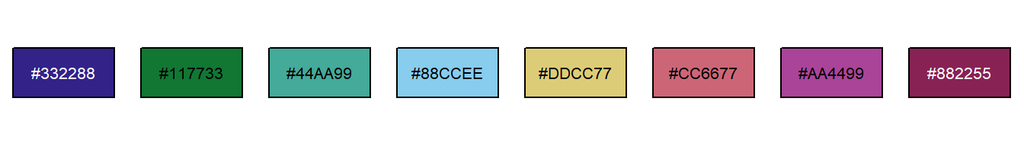

```r
par(mfrow=c(1,8), oma=c(0,0,0,0), mar = c(1,0.5,1,0.5))

plot(NULL, type="n", xlim=c(-1,1), ylim=c(-1,1), axes = FALSE, xlab = "", ylab = "")
rect(xleft = -1, ybottom = -0.5, xright =1, ytop = 0.5, lty = 1, col = "#332288")
text(0,0, "#332288", col = "white")
plot(NULL, type="n", xlim=c(-1,1), ylim=c(-1,1), axes = FALSE, xlab = "", ylab = "")
rect(xleft = -1, ybottom = -0.5, xright =1, ytop = 0.5, lty = 1, col = "#117733")
text(0,0, "#117733")
plot(NULL, type="n", xlim=c(-1,1), ylim=c(-1,1), axes = FALSE, xlab = "", ylab = "")
rect(xleft = -1, ybottom = -0.5, xright =1, ytop = 0.5, lty = 1, col = "#44AA99")
text(0,0, "#44AA99")
plot(NULL, type="n", xlim=c(-1,1), ylim=c(-1,1), axes = FALSE, xlab = "", ylab = "")
rect(xleft = -1, ybottom = -0.5, xright =1, ytop = 0.5, lty = 1, col = "#88CCEE")
text(0,0, "#88CCEE")
plot(NULL, type="n", xlim=c(-1,1), ylim=c(-1,1), axes = FALSE, xlab = "", ylab = "")
rect(xleft = -1, ybottom = -0.5, xright =1, ytop = 0.5, lty = 1, col = "#DDCC77")
text(0,0, "#DDCC77")
plot(NULL, type="n", xlim=c(-1,1), ylim=c(-1,1), axes = FALSE, xlab = "", ylab = "")
rect(xleft = -1, ybottom = -0.5, xright =1, ytop = 0.5, lty = 1, col = "#CC6677")
text(0,0, "#CC6677")
plot(NULL, type="n", xlim=c(-1,1), ylim=c(-1,1), axes = FALSE, xlab = "", ylab = "")
rect(xleft = -1, ybottom = -0.5, xright =1, ytop = 0.5, lty = 1, col = "#AA4499")
text(0,0, "#AA4499")
plot(NULL, type="n", xlim=c(-1,1), ylim=c(-1,1), axes = FALSE, xlab = "", ylab = "")
rect(xleft = -1, ybottom = -0.5, xright =1, ytop = 0.5, lty = 1, col = "#882255")
text(0,0, "#882255", col = "white")
```

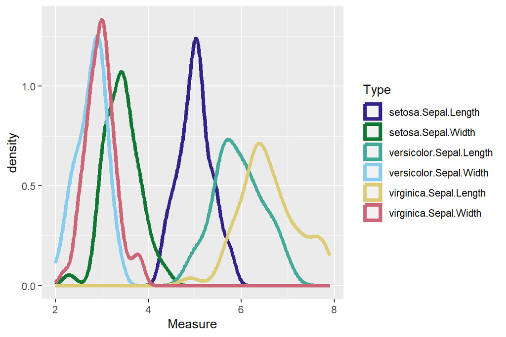

```r
iris0 = iris
Type = c(paste(iris$Species,".Sepal.Length", sep = ""),paste(iris$Species,".Sepal.Width", sep = ""))
Measure = c(iris$Sepal.Length ,iris$Sepal.Width)
irisNew = data.frame(Type = Type, Measure = Measure)
cols1 = c("#332288","#117733","#44AA99","#88CCEE","#DDCC77","#CC6677")
cols3 = c("#AA4499","#882255")
ggplot() +
      geom_density(data = irisNew, aes(x = Measure, color = Type), lwd = 1.5)+
      scale_color_manual(values = cols1)
```